# Internal structure of `eatRep`

Sebastian Weirich

January 2024

## Introduction

This vignette is intended to illustrate the internal structure of the package rather than how it works. It is therefore not aimed at users, but at developers who may wish to extend or supplement the package. The development of the package began in spring 2012 as part of the evaluation of the first “National Assessment Study” ([study description](https://www.iqb.hu-berlin.de/bt/LV2011/)) in 2011 at primary level. It was more of an “organic” process, i.e. always geared towards current concrete needs, which gradually expanded over the years. Nobody was thinking about trends back then.

## 1. The beginnings

Originally, only the functions of the survey package `survey::svymean` (for mean values) and `survey::svytable` were to be wrapped or extended with imputed data. This meant calling the respective function several times in succession and pooling the results. Since the survey functions used replication weights, but the data sets only contained jackknife variables (i.e. the variables needed to determine the weights, but not the weights themselves), the replication weights were generated beforehand by a small function `eatRep:::generate.replicates` and merged with the data. The structure of the package looked something like this:

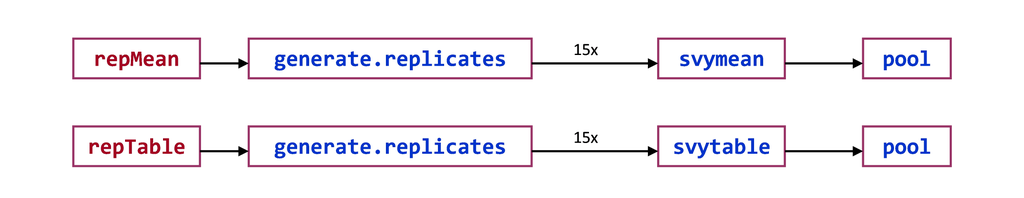

Later, more and more plausibility checks were added to catch common error conditions. The special feature: some of these checks are function-specific (i.e. are relevant for `table`, but not for `mean`), other checks are general, i.e. always apply. To avoid redundancies, the general plausibility checks and data set preparation were therefore passed to a general function `eatRep`, which itself was not user-level, but was called internally by all functions.

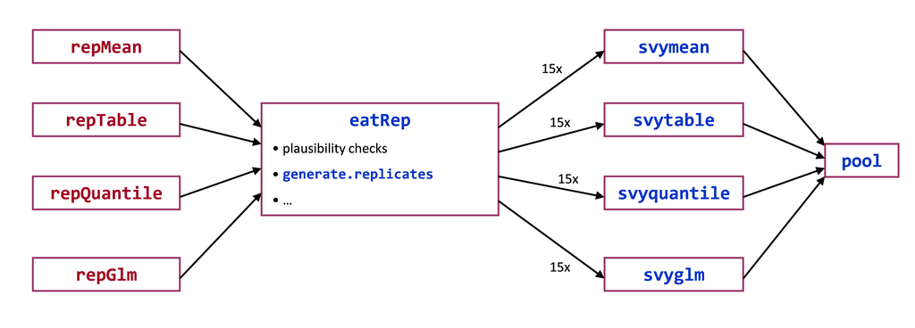

## 2. Group mean comparisons

Theoretically, group comparisons are not such a huge problem. For example, numerical mean values are calculated for boys vs. girls and the difference is tested for statistical significance. This is basically just a simple *t* test. The situation is different with polytomous variables (competence levels). The correct statistic for the question of whether the skill level distribution differs between boys and girls, for example, would be a $\chi^2$ test. However, statements of the type “Do boys fail to meet the minimum standards more often than girls?” were desired. This boils down to the question of whether the relative frequency differs between boys and girls *for competence level 1 only*. This cannot be solved with `group.differences.by` and the `table` function, as a group comparison based on the table `function` always results in a $\chi^2$ test. A workaround was therefore implemented: For statements “Do boys miss the minimum standards more often than girls?”, the polytomous competence level variable was transformed internally into dichotomous indicators and then `repMean` was called for each of these indicator variables. Here again, `group.differences.by` could be executed with the desired *t* test.

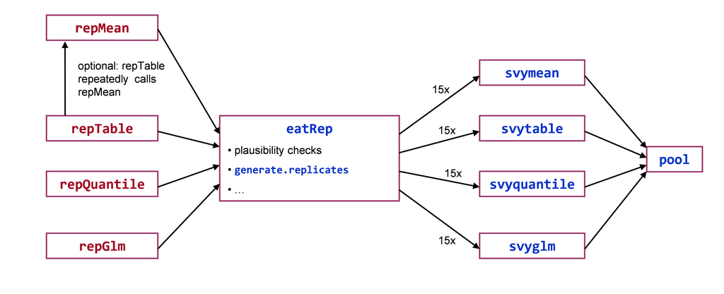

## 3. Daring more flexibility

In order to extend `eatRep` for jackknife-1, balanced repeated replicates (BRR) or for data without replication weights (“conventional mean analysis”, `conv.mean`), the number of functions to which the analyses are outsourced has been extended:

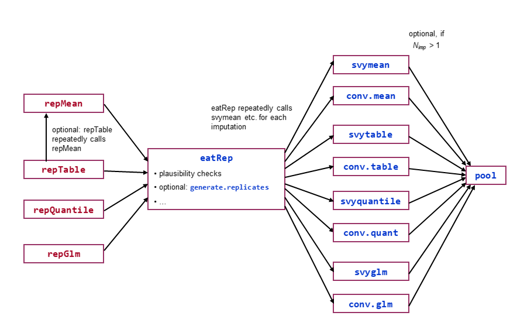

## 4. Trends and reporting

The reporting function pursued the goal (which has not yet been fully realized) of presenting the results of various functions in a reasonably uniform and clear manner. In “National Assessment Study 2015” ([study description](https://www.iqb.hu-berlin.de/bt/BT2015/)) the `eatTrend` package was designed for these analyses. It’s functionality has since been transferred to `eatRep` (some would say: occupied by `eatRep`). The basic idea is that the internal `eatRep` function calls itself repeatedly (namely once for each year); the differences between the years are then calculated in the reporting function.

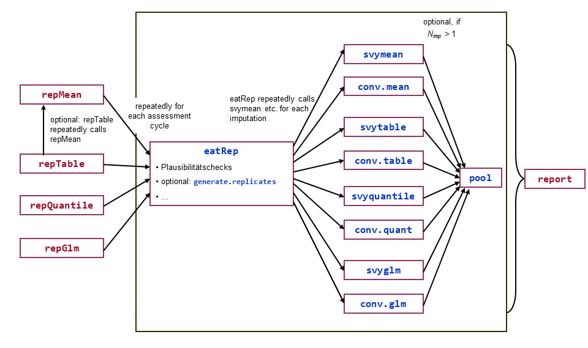

## 5. Accelerate analysis speed

For performance reasons, `eatRep` should also integrate the recently published `BIFIEsurvey` package. It cannot be easily integrated into the hierarchical structure outlined above, as `BIFIEsurvey`, unlike `survey`, handles both the generation of replication weights and pooling. The `BIFIEsurvey` functions can therefore not simply be embedded here in the same way as `svymean` etc. If users select `BIFIEsurvey`, this means that the `eatRep` module does not generate replication weights and does not create a loop to repeat `svymean` or `conv.glm` 15 times, for example, nor does it pass the results to the `pool` function. Instead, the results are transferred to `BIFIEsurvey` beforehand and the results already pooled there are only transferred back to the result structure. The results are therefore structurally the same, regardless of whether they come from `survey` or `BIFIEsurvey`.

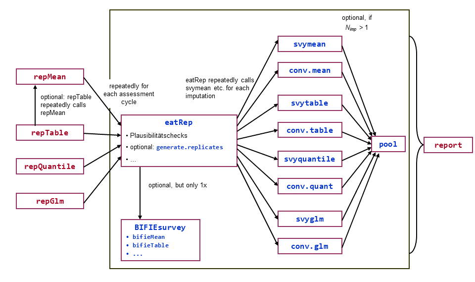

## 6. Weighted Effect Coding (WEC)

This method actually only concerns mean value comparisons of the kind “[subgroup] vs. [overall group]”, i.e. something like “do Hessian children differ from those in Germany as a whole”? Users use `repMean` with cross-level differences for this. However, WEC is based on a regression with a special contrast coding, and this means that `repMean` internally calls the `glm` function with replicate weights. This always means that the `pool` function must of course process the results of such an analysis according to the *technical* call (`glm`), but the return for the user must be according to the *content* call (`repMean`). The fact that a function `x` can utilize the results of another function `y` is beneficial, but makes it more difficult if each function has its own processing routine. The situation is similar with adjusted mean values.

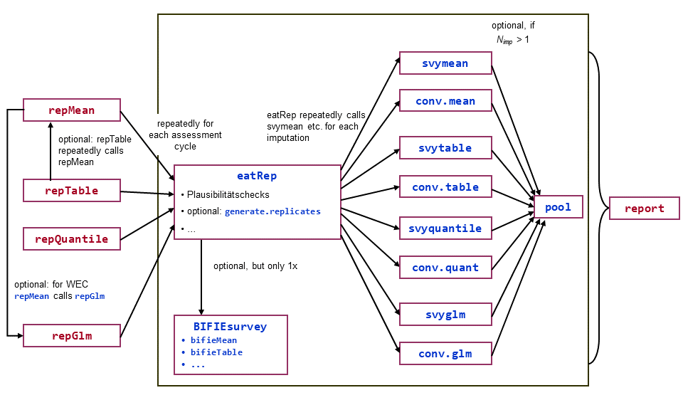

## 7. Example

For the purpose of illustration, the journey of a user command through the bowels of `eatRep` will be outlined. An arbitrary call of `repTable` will be used for this purpose. (For the sake of clarity, some arguments are listed here again with their default values):

```r
freqs  <- repTable ( datL = subdat, ID="IDSTUD", wgt="totwgt", type = "jk2",
          PSU="jkzone",  repInd = "jkrep",  imp="imp",
          groups = c("TR_BUNDESLAND", "gy"), group.splits = 0:2,
          group.differences.by = "gy", chiSquare = FALSE,
          cross.differences = TRUE, crossDiffSE = "old",
          dependent = "traitLevel", engine="survey", trend="year",
          linkErr = subset(LEs, domain == subdat[1,"kb"]))
```

1. `repTable` determines that a group comparison should take place here, but that no $\chi^2$ test is required. Therefore, `repMean` is wrapped. However, `eatRep` must taken into account that the `"mode"` column in the final result output must not contain mean, as the table function was originally called anyway.
2. The polytomous `traitLevel` variable which has 5 distinct competence levels is transformed into 5 dichotomous 0/1 indicator variables.
3. `repMean` now calls itself five times repeatedly according to the five 0/1 indicator variables. The mean value of each indicator variable corresponds to the relative frequency of the respective category.
4. Each individual `repMean` call generates exactly one `eatRep` call.
5. As the current syntax call contains a trend estimate, the function `ectRep` is called as many times in succession as there are distinct levels in the trend variable `"year"`.
6. Replicates are generated by calling `generate replicates()`, if replication analysis is needed (this is the case here), but no `BIFIEsurvey` is to be used (this is also the case here). If the user chooses `BIFIEsurvey` as engine, calling `generate replicates()` will be skipped.
7. There are several hierarchy levels here, one analysis according to level 0, two analyses according to level 1, and one analysis according to level 2, i.e. a total of four. The inner loop function now calls itself up a total of four times. At hierarchy level 0, the total population mean is computed. At hierarchy level 1, the means for each federal state are computed, and the means for the academic track and the non-academic track are computed. At hierarchy level 2, the means for the academic track and the non-academic track in each federal state are computed.
8. As the `survey` package does not process imputed data, the data set for `survey` analyses is now split into individual imputations. For 10 imputations, 10 data sets are generated. The corresponding `survey` function is now called for each imputed data set, optionally via parallel computation. The results are then pooled.

The entire process is based on a replication of replication: in the innermost loop are the jackknife replications (e.g. 100 replications for 100 jackknife zones), then the replications based on imputations (e.g. 15), then the replications based on hierarchy levels, then the replications based on trend groups, then the replications based on the number of dependent variables (0/1 indicators).